# Dataset 3 - IBM HR Employee Attrition Data

```python
import pandas as pd
from matplotlib import pyplot as plt
import seaborn as sns
```

```python
df = pd.read_csv("IBM HR Employee Attrition Data.csv", encoding='unicode_escape')
df
```

|  | ï»¿Age | Attrition | BusinessTravel | DailyRate | Department | DistanceFromHome | Education | EducationField | EmployeeCount | EmployeeNumber | ... | RelationshipSatisfaction | StandardHours | StockOptionLevel | TotalWorkingYears | TrainingTimesLastYear | WorkLifeBalance | YearsAtCompany | YearsInCurrentRole | YearsSinceLastPromotion | YearsWithCurrManager |
| --- | --- | --- | --- | --- | --- | --- | --- | --- | --- | --- | --- | --- | --- | --- | --- | --- | --- | --- | --- | --- | --- |
| 0 | 41 | Yes | Travel_Rarely | 1102 | Sales | 1 | 2 | Life Sciences | 1 | 1 | ... | 1 | 80 | 0 | 8 | 0 | 1 | 6 | 4 | 0 | 5 |
| 1 | 49 | No | Travel_Frequently | 279 | Research & Development | 8 | 1 | Life Sciences | 1 | 2 | ... | 4 | 80 | 1 | 10 | 3 | 3 | 10 | 7 | 1 | 7 |
| 2 | 37 | Yes | Travel_Rarely | 1373 | Research & Development | 2 | 2 | Other | 1 | 4 | ... | 2 | 80 | 0 | 7 | 3 | 3 | 0 | 0 | 0 | 0 |
| 3 | 33 | No | Travel_Frequently | 1392 | Research & Development | 3 | 4 | Life Sciences | 1 | 5 | ... | 3 | 80 | 0 | 8 | 3 | 3 | 8 | 7 | 3 | 0 |
| 4 | 27 | No | Travel_Rarely | 591 | Research & Development | 2 | 1 | Medical | 1 | 7 | ... | 4 | 80 | 1 | 6 | 3 | 3 | 2 | 2 | 2 | 2 |
| ... | ... | ... | ... | ... | ... | ... | ... | ... | ... | ... | ... | ... | ... | ... | ... | ... | ... | ... | ... | ... | ... |
| 1465 | 36 | No | Travel_Frequently | 884 | Research & Development | 23 | 2 | Medical | 1 | 2061 | ... | 3 | 80 | 1 | 17 | 3 | 3 | 5 | 2 | 0 | 3 |
| 1466 | 39 | No | Travel_Rarely | 613 | Research & Development | 6 | 1 | Medical | 1 | 2062 | ... | 1 | 80 | 1 | 9 | 5 | 3 | 7 | 7 | 1 | 7 |
| 1467 | 27 | No | Travel_Rarely | 155 | Research & Development | 4 | 3 | Life Sciences | 1 | 2064 | ... | 2 | 80 | 1 | 6 | 0 | 3 | 6 | 2 | 0 | 3 |
| 1468 | 49 | No | Travel_Frequently | 1023 | Sales | 2 | 3 | Medical | 1 | 2065 | ... | 4 | 80 | 0 | 17 | 3 | 2 | 9 | 6 | 0 | 8 |
| 1469 | 34 | No | Travel_Rarely | 628 | Research & Development | 8 | 3 | Medical | 1 | 2068 | ... | 1 | 80 | 0 | 6 | 3 | 4 | 4 | 3 | 1 | 2 |

1470 rows × 35 columns

```python
df = df.rename(columns = {"ï»¿Age": "Age"})
```

```python
df.columns
```

```
Index(['Age', 'Attrition', 'BusinessTravel', 'DailyRate', 'Department',
       'DistanceFromHome', 'Education', 'EducationField', 'EmployeeCount',
       'EmployeeNumber', 'EnvironmentSatisfaction', 'Gender', 'HourlyRate',
       'JobInvolvement', 'JobLevel', 'JobRole', 'JobSatisfaction',
       'MaritalStatus', 'MonthlyIncome', 'MonthlyRate', 'NumCompaniesWorked',
       'Over18', 'OverTime', 'PercentSalaryHike', 'PerformanceRating',
       'RelationshipSatisfaction', 'StandardHours', 'StockOptionLevel',
       'TotalWorkingYears', 'TrainingTimesLastYear', 'WorkLifeBalance',
       'YearsAtCompany', 'YearsInCurrentRole', 'YearsSinceLastPromotion',
       'YearsWithCurrManager'],
      dtype='object')
```

```python
df.info()
```

```
<class 'pandas.core.frame.DataFrame'>
RangeIndex: 1470 entries, 0 to 1469
Data columns (total 35 columns):
 #   Column                    Non-Null Count  Dtype
---  ------                    --------------  -----
 0   Age                       1470 non-null   int64
 1   Attrition                 1470 non-null   object
 2   BusinessTravel            1470 non-null   object
 3   DailyRate                 1470 non-null   int64
 4   Department                1470 non-null   object
 5   DistanceFromHome          1470 non-null   int64
 6   Education                 1470 non-null   int64
 7   EducationField            1470 non-null   object
 8   EmployeeCount             1470 non-null   int64
 9   EmployeeNumber            1470 non-null   int64
```

[output cut: 27 more lines]

```python
df.shape
```

```
(1470, 35)
```

```python
df.describe().round(2)
```

|  | Age | DailyRate | DistanceFromHome | Education | EmployeeCount | EmployeeNumber | EnvironmentSatisfaction | HourlyRate | JobInvolvement | JobLevel | ... | RelationshipSatisfaction | StandardHours | StockOptionLevel | TotalWorkingYears | TrainingTimesLastYear | WorkLifeBalance | YearsAtCompany | YearsInCurrentRole | YearsSinceLastPromotion | YearsWithCurrManager |
| --- | --- | --- | --- | --- | --- | --- | --- | --- | --- | --- | --- | --- | --- | --- | --- | --- | --- | --- | --- | --- | --- |
| count | 1470.00 | 1470.00 | 1470.00 | 1470.00 | 1470.0 | 1470.00 | 1470.00 | 1470.00 | 1470.00 | 1470.00 | ... | 1470.00 | 1470.0 | 1470.00 | 1470.00 | 1470.00 | 1470.00 | 1470.00 | 1470.00 | 1470.00 | 1470.00 |
| mean | 36.92 | 802.49 | 9.19 | 2.91 | 1.0 | 1024.87 | 2.72 | 65.89 | 2.73 | 2.06 | ... | 2.71 | 80.0 | 0.79 | 11.28 | 2.80 | 2.76 | 7.01 | 4.23 | 2.19 | 4.12 |
| std | 9.14 | 403.51 | 8.11 | 1.02 | 0.0 | 602.02 | 1.09 | 20.33 | 0.71 | 1.11 | ... | 1.08 | 0.0 | 0.85 | 7.78 | 1.29 | 0.71 | 6.13 | 3.62 | 3.22 | 3.57 |
| min | 18.00 | 102.00 | 1.00 | 1.00 | 1.0 | 1.00 | 1.00 | 30.00 | 1.00 | 1.00 | ... | 1.00 | 80.0 | 0.00 | 0.00 | 0.00 | 1.00 | 0.00 | 0.00 | 0.00 | 0.00 |
| 25% | 30.00 | 465.00 | 2.00 | 2.00 | 1.0 | 491.25 | 2.00 | 48.00 | 2.00 | 1.00 | ... | 2.00 | 80.0 | 0.00 | 6.00 | 2.00 | 2.00 | 3.00 | 2.00 | 0.00 | 2.00 |
| 50% | 36.00 | 802.00 | 7.00 | 3.00 | 1.0 | 1020.50 | 3.00 | 66.00 | 3.00 | 2.00 | ... | 3.00 | 80.0 | 1.00 | 10.00 | 3.00 | 3.00 | 5.00 | 3.00 | 1.00 | 3.00 |
| 75% | 43.00 | 1157.00 | 14.00 | 4.00 | 1.0 | 1555.75 | 4.00 | 83.75 | 3.00 | 3.00 | ... | 4.00 | 80.0 | 1.00 | 15.00 | 3.00 | 3.00 | 9.00 | 7.00 | 3.00 | 7.00 |
| max | 60.00 | 1499.00 | 29.00 | 5.00 | 1.0 | 2068.00 | 4.00 | 100.00 | 4.00 | 5.00 | ... | 4.00 | 80.0 | 3.00 | 40.00 | 6.00 | 4.00 | 40.00 | 18.00 | 15.00 | 17.00 |

8 rows × 26 columns

```python
df.nunique()
```

```
Age                           43
Attrition                      2
BusinessTravel                 3
DailyRate                    886
Department                     3
DistanceFromHome              29
Education                      5
EducationField                 6
EmployeeCount                  1
EmployeeNumber              1470
EnvironmentSatisfaction        4
Gender                         2
HourlyRate                    71
JobInvolvement                 4
JobLevel                       5
JobRole                        9
JobSatisfaction                4
MaritalStatus                  3
MonthlyIncome               1349
MonthlyRate                 1427
NumCompaniesWorked            10
Over18                         1
OverTime                       2
PercentSalaryHike             15
PerformanceRating              2
RelationshipSatisfaction       4
StandardHours                  1
StockOptionLevel               4
TotalWorkingYears             40
TrainingTimesLastYear          7
WorkLifeBalance                4
YearsAtCompany                37
YearsInCurrentRole            19
YearsSinceLastPromotion       16
YearsWithCurrManager          18
dtype: int64
```

## [IBM HR Employee Attrition EDA Report](http://localhost:8888/view/All%20Analysis%20Folders%20right%20here/Working%20on%20Real-World%20Datasets/IBM_HR_EDA_Report.html)

**Drop the constant columns from the dataset.**

```python
df = df.drop(columns=["EmployeeCount", "Over18", "StandardHours"])
```

```python
df.shape
```

```
(1470, 32)
```

## Correlation Heatmap - Relationships b/w Features

**Numeric Columns**

```python
numeric_df = df.select_dtypes(include=["int", "float"])
numeric_df.columns
```

```
Index(['Age', 'DailyRate', 'DistanceFromHome', 'Education', 'EmployeeNumber',
       'EnvironmentSatisfaction', 'HourlyRate', 'JobInvolvement', 'JobLevel',
       'JobSatisfaction', 'MonthlyIncome', 'MonthlyRate', 'NumCompaniesWorked',
       'PercentSalaryHike', 'PerformanceRating', 'RelationshipSatisfaction',
       'StockOptionLevel', 'TotalWorkingYears', 'TrainingTimesLastYear',
       'WorkLifeBalance', 'YearsAtCompany', 'YearsInCurrentRole',
       'YearsSinceLastPromotion', 'YearsWithCurrManager'],
      dtype='object')
```

**Categorical Columns**

```python
df.select_dtypes(exclude=["int", "float"]).columns
```

```
Index(['Attrition', 'BusinessTravel', 'Department', 'EducationField', 'Gender',
       'JobRole', 'MaritalStatus', 'OverTime'],
      dtype='object')
```

**Correlation Matrix Heatmap**

```python
corr_matrix = numeric_df.corr()
corr_matrix
```

|  | Age | DailyRate | DistanceFromHome | Education | EmployeeNumber | EnvironmentSatisfaction | HourlyRate | JobInvolvement | JobLevel | JobSatisfaction | ... | PerformanceRating | RelationshipSatisfaction | StockOptionLevel | TotalWorkingYears | TrainingTimesLastYear | WorkLifeBalance | YearsAtCompany | YearsInCurrentRole | YearsSinceLastPromotion | YearsWithCurrManager |
| --- | --- | --- | --- | --- | --- | --- | --- | --- | --- | --- | --- | --- | --- | --- | --- | --- | --- | --- | --- | --- | --- |
| Age | 1.000000 | 0.010661 | -0.001686 | 0.208034 | -0.010145 | 0.010146 | 0.024287 | 0.029820 | 0.509604 | -0.004892 | ... | 0.001904 | 0.053535 | 0.037510 | 0.680381 | -0.019621 | -0.021490 | 0.311309 | 0.212901 | 0.216513 | 0.202089 |
| DailyRate | 0.010661 | 1.000000 | -0.004985 | -0.016806 | -0.050990 | 0.018355 | 0.023381 | 0.046135 | 0.002966 | 0.030571 | ... | 0.000473 | 0.007846 | 0.042143 | 0.014515 | 0.002453 | -0.037848 | -0.034055 | 0.009932 | -0.033229 | -0.026363 |
| DistanceFromHome | -0.001686 | -0.004985 | 1.000000 | 0.021042 | 0.032916 | -0.016075 | 0.031131 | 0.008783 | 0.005303 | -0.003669 | ... | 0.027110 | 0.006557 | 0.044872 | 0.004628 | -0.036942 | -0.026556 | 0.009508 | 0.018845 | 0.010029 | 0.014406 |
| Education | 0.208034 | -0.016806 | 0.021042 | 1.000000 | 0.042070 | -0.027128 | 0.016775 | 0.042438 | 0.101589 | -0.011296 | ... | -0.024539 | -0.009118 | 0.018422 | 0.148280 | -0.025100 | 0.009819 | 0.069114 | 0.060236 | 0.054254 | 0.069065 |
| EmployeeNumber | -0.010145 | -0.050990 | 0.032916 | 0.042070 | 1.000000 | 0.017621 | 0.035179 | -0.006888 | -0.018519 | -0.046247 | ... | -0.020359 | -0.069861 | 0.062227 | -0.014365 | 0.023603 | 0.010309 | -0.011240 | -0.008416 | -0.009019 | -0.009197 |
| EnvironmentSatisfaction | 0.010146 | 0.018355 | -0.016075 | -0.027128 | 0.017621 | 1.000000 | -0.049857 | -0.008278 | 0.001212 | -0.006784 | ... | -0.029548 | 0.007665 | 0.003432 | -0.002693 | -0.019359 | 0.027627 | 0.001458 | 0.018007 | 0.016194 | -0.004999 |
| HourlyRate | 0.024287 | 0.023381 | 0.031131 | 0.016775 | 0.035179 | -0.049857 | 1.000000 | 0.042861 | -0.027853 | -0.071335 | ... | -0.002172 | 0.001330 | 0.050263 | -0.002334 | -0.008548 | -0.004607 | -0.019582 | -0.024106 | -0.026716 | -0.020123 |
| JobInvolvement | 0.029820 | 0.046135 | 0.008783 | 0.042438 | -0.006888 | -0.008278 | 0.042861 | 1.000000 | -0.012630 | -0.021476 | ... | -0.029071 | 0.034297 | 0.021523 | -0.005533 | -0.015338 | -0.014617 | -0.021355 | 0.008717 | -0.024184 | 0.025976 |
| JobLevel | 0.509604 | 0.002966 | 0.005303 | 0.101589 | -0.018519 | 0.001212 | -0.027853 | -0.012630 | 1.000000 | -0.001944 | ... | -0.021222 | 0.021642 | 0.013984 | 0.782208 | -0.018191 | 0.037818 | 0.534739 | 0.389447 | 0.353885 | 0.375281 |
| JobSatisfaction | -0.004892 | 0.030571 | -0.003669 | -0.011296 | -0.046247 | -0.006784 | -0.071335 | -0.021476 | -0.001944 | 1.000000 | ... | 0.002297 | -0.012454 | 0.010690 | -0.020185 | -0.005779 | -0.019459 | -0.003803 | -0.002305 | -0.018214 | -0.027656 |
| MonthlyIncome | 0.497855 | 0.007707 | -0.017014 | 0.094961 | -0.014829 | -0.006259 | -0.015794 | -0.015271 | 0.950300 | -0.007157 | ... | -0.017120 | 0.025873 | 0.005408 | 0.772893 | -0.021736 | 0.030683 | 0.514285 | 0.363818 | 0.344978 | 0.344079 |
| MonthlyRate | 0.028051 | -0.032182 | 0.027473 | -0.026084 | 0.012648 | 0.037600 | -0.015297 | -0.016322 | 0.039563 | 0.000644 | ... | -0.009811 | -0.004085 | -0.034323 | 0.026442 | 0.001467 | 0.007963 | -0.023655 | -0.012815 | 0.001567 | -0.036746 |
| NumCompaniesWorked | 0.299635 | 0.038153 | -0.029251 | 0.126317 | -0.001251 | 0.012594 | 0.022157 | 0.015012 | 0.142501 | -0.055699 | ... | -0.014095 | 0.052733 | 0.030075 | 0.237639 | -0.066054 | -0.008366 | -0.118421 | -0.090754 | -0.036814 | -0.110319 |
| PercentSalaryHike | 0.003634 | 0.022704 | 0.040235 | -0.011111 | -0.012944 | -0.031701 | -0.009062 | -0.017205 | -0.034730 | 0.020002 | ... | 0.773550 | -0.040490 | 0.007528 | -0.020608 | -0.005221 | -0.003280 | -0.035991 | -0.001520 | -0.022154 | -0.011985 |
| PerformanceRating | 0.001904 | 0.000473 | 0.027110 | -0.024539 | -0.020359 | -0.029548 | -0.002172 | -0.029071 | -0.021222 | 0.002297 | ... | 1.000000 | -0.031351 | 0.003506 | 0.006744 | -0.015579 | 0.002572 | 0.003435 | 0.034986 | 0.017896 | 0.022827 |
| RelationshipSatisfaction | 0.053535 | 0.007846 | 0.006557 | -0.009118 | -0.069861 | 0.007665 | 0.001330 | 0.034297 | 0.021642 | -0.012454 | ... | -0.031351 | 1.000000 | -0.045952 | 0.024054 | 0.002497 | 0.019604 | 0.019367 | -0.015123 | 0.033493 | -0.000867 |
| StockOptionLevel | 0.037510 | 0.042143 | 0.044872 | 0.018422 | 0.062227 | 0.003432 | 0.050263 | 0.021523 | 0.013984 | 0.010690 | ... | 0.003506 | -0.045952 | 1.000000 | 0.010136 | 0.011274 | 0.004129 | 0.015058 | 0.050818 | 0.014352 | 0.024698 |
| TotalWorkingYears | 0.680381 | 0.014515 | 0.004628 | 0.148280 | -0.014365 | -0.002693 | -0.002334 | -0.005533 | 0.782208 | -0.020185 | ... | 0.006744 | 0.024054 | 0.010136 | 1.000000 | -0.035662 | 0.001008 | 0.628133 | 0.460365 | 0.404858 | 0.459188 |
| TrainingTimesLastYear | -0.019621 | 0.002453 | -0.036942 | -0.025100 | 0.023603 | -0.019359 | -0.008548 | -0.015338 | -0.018191 | -0.005779 | ... | -0.015579 | 0.002497 | 0.011274 | -0.035662 | 1.000000 | 0.028072 | 0.003569 | -0.005738 | -0.002067 | -0.004096 |
| WorkLifeBalance | -0.021490 | -0.037848 | -0.026556 | 0.009819 | 0.010309 | 0.027627 | -0.004607 | -0.014617 | 0.037818 | -0.019459 | ... | 0.002572 | 0.019604 | 0.004129 | 0.001008 | 0.028072 | 1.000000 | 0.012089 | 0.049856 | 0.008941 | 0.002759 |
| YearsAtCompany | 0.311309 | -0.034055 | 0.009508 | 0.069114 | -0.011240 | 0.001458 | -0.019582 | -0.021355 | 0.534739 | -0.003803 | ... | 0.003435 | 0.019367 | 0.015058 | 0.628133 | 0.003569 | 0.012089 | 1.000000 | 0.758754 | 0.618409 | 0.769212 |
| YearsInCurrentRole | 0.212901 | 0.009932 | 0.018845 | 0.060236 | -0.008416 | 0.018007 | -0.024106 | 0.008717 | 0.389447 | -0.002305 | ... | 0.034986 | -0.015123 | 0.050818 | 0.460365 | -0.005738 | 0.049856 | 0.758754 | 1.000000 | 0.548056 | 0.714365 |
| YearsSinceLastPromotion | 0.216513 | -0.033229 | 0.010029 | 0.054254 | -0.009019 | 0.016194 | -0.026716 | -0.024184 | 0.353885 | -0.018214 | ... | 0.017896 | 0.033493 | 0.014352 | 0.404858 | -0.002067 | 0.008941 | 0.618409 | 0.548056 | 1.000000 | 0.510224 |
| YearsWithCurrManager | 0.202089 | -0.026363 | 0.014406 | 0.069065 | -0.009197 | -0.004999 | -0.020123 | 0.025976 | 0.375281 | -0.027656 | ... | 0.022827 | -0.000867 | 0.024698 | 0.459188 | -0.004096 | 0.002759 | 0.769212 | 0.714365 | 0.510224 | 1.000000 |

24 rows × 24 columns

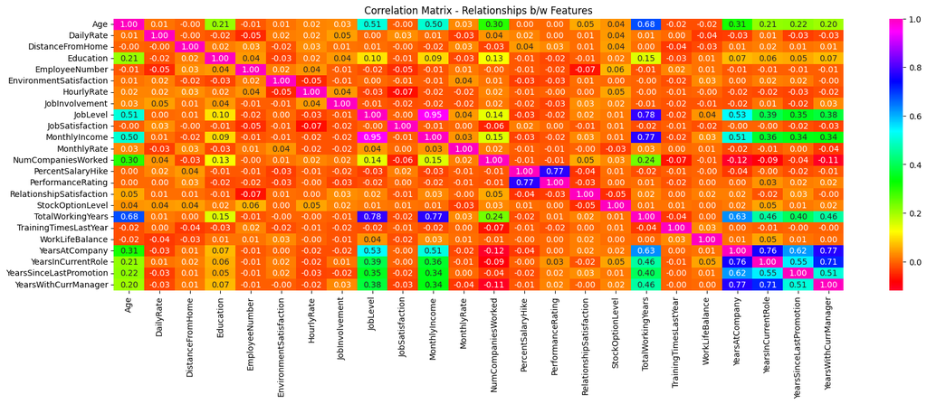

```python
plt.figure(figsize = (20, 6))
sns.heatmap(data = corr_matrix, annot = True, cmap = "gist_rainbow", fmt = ".2f")
plt.title("Correlation Matrix - Relationships b/w Features")
plt.show()
```

## Histograms for the columns with a significant number of Zeros

**Number of Companies Worked**

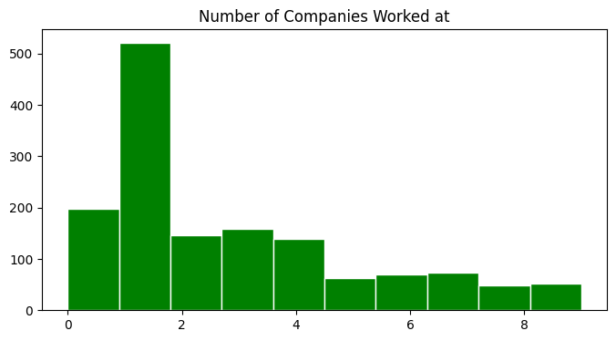

```python
plt.figure(figsize = (8, 4))
plt.hist(df["NumCompaniesWorked"], bins = 10, edgecolor = "w", color = "g")
plt.title("Number of Companies Worked at")
plt.show()
```

**Last Year Training Times**

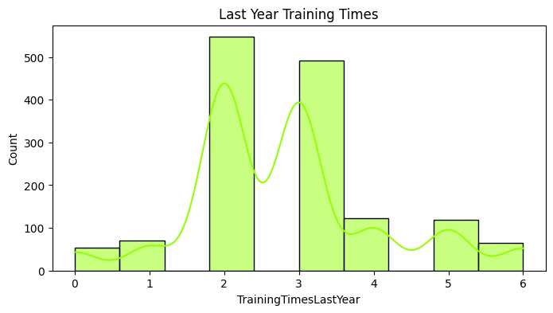

```python
plt.figure(figsize = (8, 4))
sns.histplot(df["TrainingTimesLastYear"], bins = 10,
             color = "#93ff05", kde = True) # kde=True adds a kernel density estimate
plt.title("Last Year Training Times")
plt.show()
```

**Number of Years at Company**

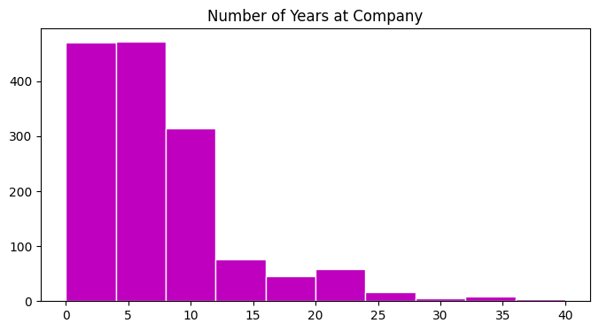

```python
plt.figure(figsize = (8, 4))
plt.hist(df["YearsAtCompany"], bins = 10, edgecolor = "w", color = "m")
plt.title("Number of Years at Company")
plt.show()
```

**Years in Current Role**

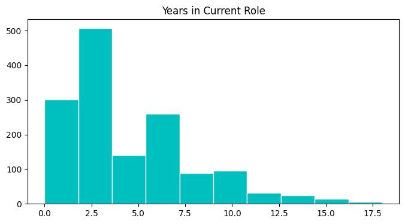

```python
plt.figure(figsize = (8, 4))
plt.hist(df["YearsInCurrentRole"], bins = 10, edgecolor = "w", color = "c")
plt.title("Years in Current Role")
plt.show()
```

**Number of Years since Last Promotion**

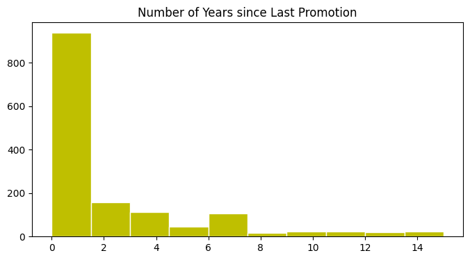

```python
plt.figure(figsize = (8, 4))
plt.hist(df["YearsSinceLastPromotion"], bins = 10, edgecolor = "w", color = "y")
plt.title("Number of Years since Last Promotion")
plt.show()
```

**Years with Current Manager**

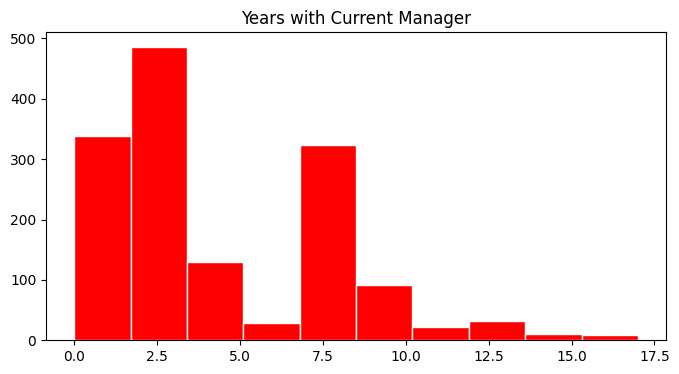

```python
plt.figure(figsize = (8, 4))
plt.hist(df["YearsWithCurrManager"], bins = 10, edgecolor = "w", color = "r")
plt.title("Years with Current Manager")
plt.show()
```

## EDA

**Display the first 5 rows of the dataset.**

```python
df.head()
```

|  | Age | Attrition | BusinessTravel | DailyRate | Department | DistanceFromHome | Education | EducationField | EmployeeNumber | EnvironmentSatisfaction | ... | PerformanceRating | RelationshipSatisfaction | StockOptionLevel | TotalWorkingYears | TrainingTimesLastYear | WorkLifeBalance | YearsAtCompany | YearsInCurrentRole | YearsSinceLastPromotion | YearsWithCurrManager |
| --- | --- | --- | --- | --- | --- | --- | --- | --- | --- | --- | --- | --- | --- | --- | --- | --- | --- | --- | --- | --- | --- |
| 0 | 41 | Yes | Travel_Rarely | 1102 | Sales | 1 | 2 | Life Sciences | 1 | 2 | ... | 3 | 1 | 0 | 8 | 0 | 1 | 6 | 4 | 0 | 5 |
| 1 | 49 | No | Travel_Frequently | 279 | Research & Development | 8 | 1 | Life Sciences | 2 | 3 | ... | 4 | 4 | 1 | 10 | 3 | 3 | 10 | 7 | 1 | 7 |
| 2 | 37 | Yes | Travel_Rarely | 1373 | Research & Development | 2 | 2 | Other | 4 | 4 | ... | 3 | 2 | 0 | 7 | 3 | 3 | 0 | 0 | 0 | 0 |
| 3 | 33 | No | Travel_Frequently | 1392 | Research & Development | 3 | 4 | Life Sciences | 5 | 4 | ... | 3 | 3 | 0 | 8 | 3 | 3 | 8 | 7 | 3 | 0 |
| 4 | 27 | No | Travel_Rarely | 591 | Research & Development | 2 | 1 | Medical | 7 | 1 | ... | 3 | 4 | 1 | 6 | 3 | 3 | 2 | 2 | 2 | 2 |

5 rows × 32 columns

**Check the number of rows and columns.**

```python
df.shape
```

```
(1470, 32)
```

**Get summary statistics for numerical columns.**

```python
df.describe().round(2)
```

|  | Age | DailyRate | DistanceFromHome | Education | EmployeeNumber | EnvironmentSatisfaction | HourlyRate | JobInvolvement | JobLevel | JobSatisfaction | ... | PerformanceRating | RelationshipSatisfaction | StockOptionLevel | TotalWorkingYears | TrainingTimesLastYear | WorkLifeBalance | YearsAtCompany | YearsInCurrentRole | YearsSinceLastPromotion | YearsWithCurrManager |
| --- | --- | --- | --- | --- | --- | --- | --- | --- | --- | --- | --- | --- | --- | --- | --- | --- | --- | --- | --- | --- | --- |
| count | 1470.00 | 1470.00 | 1470.00 | 1470.00 | 1470.00 | 1470.00 | 1470.00 | 1470.00 | 1470.00 | 1470.00 | ... | 1470.00 | 1470.00 | 1470.00 | 1470.00 | 1470.00 | 1470.00 | 1470.00 | 1470.00 | 1470.00 | 1470.00 |
| mean | 36.92 | 802.49 | 9.19 | 2.91 | 1024.87 | 2.72 | 65.89 | 2.73 | 2.06 | 2.73 | ... | 3.15 | 2.71 | 0.79 | 11.28 | 2.80 | 2.76 | 7.01 | 4.23 | 2.19 | 4.12 |
| std | 9.14 | 403.51 | 8.11 | 1.02 | 602.02 | 1.09 | 20.33 | 0.71 | 1.11 | 1.10 | ... | 0.36 | 1.08 | 0.85 | 7.78 | 1.29 | 0.71 | 6.13 | 3.62 | 3.22 | 3.57 |
| min | 18.00 | 102.00 | 1.00 | 1.00 | 1.00 | 1.00 | 30.00 | 1.00 | 1.00 | 1.00 | ... | 3.00 | 1.00 | 0.00 | 0.00 | 0.00 | 1.00 | 0.00 | 0.00 | 0.00 | 0.00 |
| 25% | 30.00 | 465.00 | 2.00 | 2.00 | 491.25 | 2.00 | 48.00 | 2.00 | 1.00 | 2.00 | ... | 3.00 | 2.00 | 0.00 | 6.00 | 2.00 | 2.00 | 3.00 | 2.00 | 0.00 | 2.00 |
| 50% | 36.00 | 802.00 | 7.00 | 3.00 | 1020.50 | 3.00 | 66.00 | 3.00 | 2.00 | 3.00 | ... | 3.00 | 3.00 | 1.00 | 10.00 | 3.00 | 3.00 | 5.00 | 3.00 | 1.00 | 3.00 |
| 75% | 43.00 | 1157.00 | 14.00 | 4.00 | 1555.75 | 4.00 | 83.75 | 3.00 | 3.00 | 4.00 | ... | 3.00 | 4.00 | 1.00 | 15.00 | 3.00 | 3.00 | 9.00 | 7.00 | 3.00 | 7.00 |
| max | 60.00 | 1499.00 | 29.00 | 5.00 | 2068.00 | 4.00 | 100.00 | 4.00 | 5.00 | 4.00 | ... | 4.00 | 4.00 | 3.00 | 40.00 | 6.00 | 4.00 | 40.00 | 18.00 | 15.00 | 17.00 |

8 rows × 24 columns

**Identify any missing values in the dataset.**

```python
df.isnull().sum()
```

```
Age                         0
Attrition                   0
BusinessTravel              0
DailyRate                   0
Department                  0
DistanceFromHome            0
Education                   0
EducationField              0
EmployeeNumber              0
EnvironmentSatisfaction     0
Gender                      0
HourlyRate                  0
JobInvolvement              0
JobLevel                    0
JobRole                     0
JobSatisfaction             0
MaritalStatus               0
MonthlyIncome               0
MonthlyRate                 0
NumCompaniesWorked          0
OverTime                    0
PercentSalaryHike           0
PerformanceRating           0
RelationshipSatisfaction    0
StockOptionLevel            0
TotalWorkingYears           0
TrainingTimesLastYear       0
WorkLifeBalance             0
YearsAtCompany              0
YearsInCurrentRole          0
YearsSinceLastPromotion     0
YearsWithCurrManager        0
dtype: int64
```

**Check for duplicate records.**

```python
df[df.duplicated()]
```

|  | Age | Attrition | BusinessTravel | DailyRate | Department | DistanceFromHome | Education | EducationField | EmployeeNumber | EnvironmentSatisfaction | ... | PerformanceRating | RelationshipSatisfaction | StockOptionLevel | TotalWorkingYears | TrainingTimesLastYear | WorkLifeBalance | YearsAtCompany | YearsInCurrentRole | YearsSinceLastPromotion | YearsWithCurrManager |
| --- | --- | --- | --- | --- | --- | --- | --- | --- | --- | --- | --- | --- | --- | --- | --- | --- | --- | --- | --- | --- | --- |

0 rows × 32 columns

### Data Type Analysis

**Display the data types of each column.**

```python
df.dtypes
```

```
Age                          int64
Attrition                   object
BusinessTravel              object
DailyRate                    int64
Department                  object
DistanceFromHome             int64
Education                    int64
EducationField              object
EmployeeNumber               int64
EnvironmentSatisfaction      int64
Gender                      object
HourlyRate                   int64
JobInvolvement               int64
JobLevel                     int64
JobRole                     object
JobSatisfaction              int64
MaritalStatus               object
MonthlyIncome                int64
MonthlyRate                  int64
NumCompaniesWorked           int64
OverTime                    object
PercentSalaryHike            int64
PerformanceRating            int64
RelationshipSatisfaction     int64
StockOptionLevel             int64
TotalWorkingYears            int64
TrainingTimesLastYear        int64
WorkLifeBalance              int64
YearsAtCompany               int64
YearsInCurrentRole           int64
YearsSinceLastPromotion      int64
YearsWithCurrManager         int64
dtype: object
```

**Identify categorical and numerical columns separately.**

```python
df.select_dtypes(include=["int", "float"]).columns
```

```
Index(['Age', 'DailyRate', 'DistanceFromHome', 'Education', 'EmployeeNumber',
       'EnvironmentSatisfaction', 'HourlyRate', 'JobInvolvement', 'JobLevel',
       'JobSatisfaction', 'MonthlyIncome', 'MonthlyRate', 'NumCompaniesWorked',
       'PercentSalaryHike', 'PerformanceRating', 'RelationshipSatisfaction',
       'StockOptionLevel', 'TotalWorkingYears', 'TrainingTimesLastYear',
       'WorkLifeBalance', 'YearsAtCompany', 'YearsInCurrentRole',
       'YearsSinceLastPromotion', 'YearsWithCurrManager'],
      dtype='object')
```

```python
df.select_dtypes(exclude=["int", "float"]).columns
```

```
Index(['Attrition', 'BusinessTravel', 'Department', 'EducationField', 'Gender',
       'JobRole', 'MaritalStatus', 'OverTime'],
      dtype='object')
```

### Univariate Analysis

**Plot the distribution of **Age**, **Monthly Income**, and **Total Working Years** using histograms.**

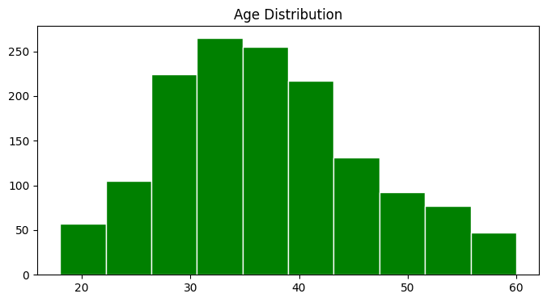

```python
plt.figure(figsize = (8, 4))
plt.hist(df["Age"], bins = 10, edgecolor = "w", color = "g")
plt.title("Age Distribution")
plt.show()
```

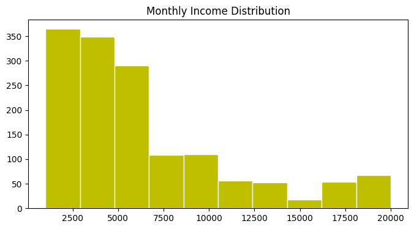

```python
plt.figure(figsize = (8, 4))
plt.hist(df["MonthlyIncome"], bins = 10, edgecolor = "w", color = "y")
plt.title("Monthly Income Distribution")
plt.show()
```

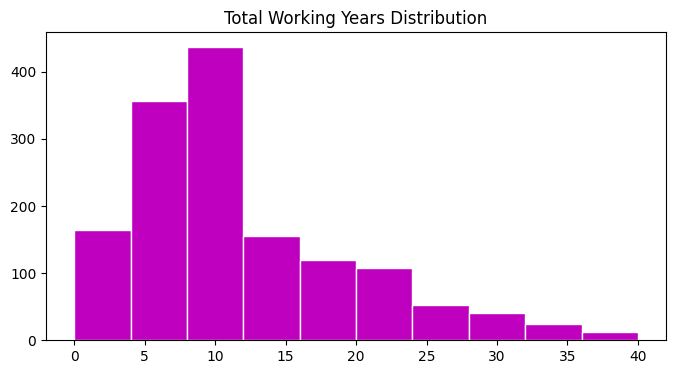

```python
plt.figure(figsize = (8, 4))
plt.hist(df["TotalWorkingYears"], bins = 10, edgecolor = "w", color = "m")
plt.title("Total Working Years Distribution")
plt.show()
```

**Analyze the frequency of categorical columns: **Job Role**, **Department**, and **Education Field** using bar charts.**

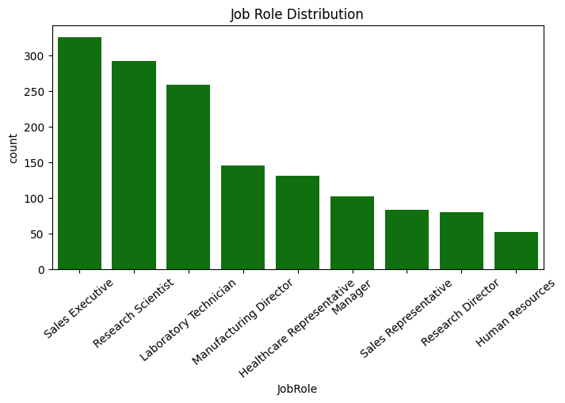

```python
plt.figure(figsize = (8, 4))
sns.countplot(x = df["JobRole"], color = "g")
plt.title("Job Role Distribution")
plt.xticks(rotation = 40)
plt.show()
```

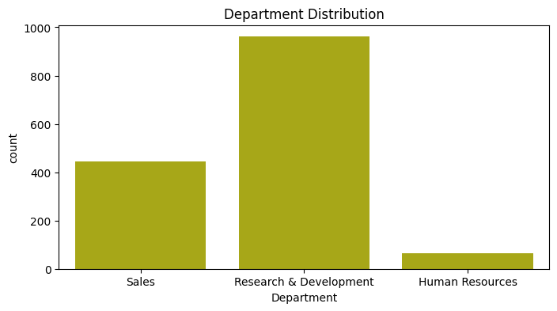

```python
plt.figure(figsize = (8, 4))
sns.countplot(x = df["Department"], color = "y")
plt.title("Department Distribution")
plt.show()
```

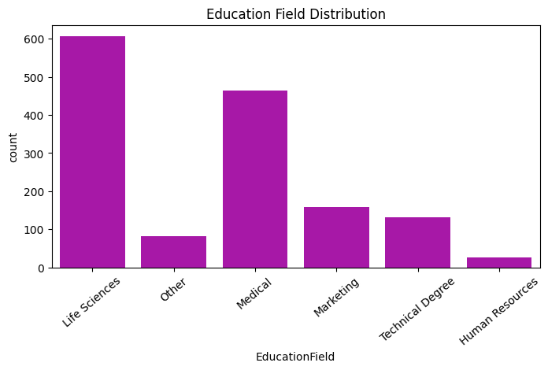

```python
plt.figure(figsize = (8, 4))
sns.countplot(x = df["EducationField"], color = "m")
plt.title("Education Field Distribution")
plt.xticks(rotation = 40)
plt.show()
```

### Attrition Analysis

**Find the percentage of employees who have left **(Attrition = "Yes")** vs. those who stayed **(Attrition = "No")**.**

```python
left_count = df["Attrition"].value_counts()["Yes"]
stayed_count = df["Attrition"].value_counts()["No"]
total_emps = df.shape[0]
```

```python
left_per = round((left_count / total_emps) * 100, 2)
left_per
```

```
16.12
```

```python
stayed_per = round((stayed_count / total_emps) * 100, 2)
stayed_per
```

```
83.88
```

**Create a count plot to visualize the Attrition distribution.**

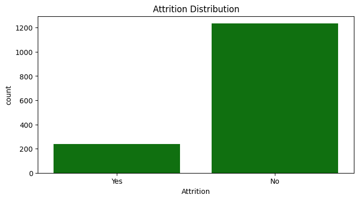

```python
plt.figure(figsize = (8, 4))
sns.countplot(x = df["Attrition"], color = "g")
plt.title("Attrition Distribution")
plt.show()
```

**Compare Average **Monthly Income** of employees who left vs. those who stayed.**

```python
left_df = df[df['Attrition'] == 'Yes']
stayed_df = df[df['Attrition'] == 'No']
```

```python
avg_income_left = left_df['MonthlyIncome'].mean().round(2)
avg_income_stayed = stayed_df['MonthlyIncome'].mean().round(2)
```

```python
avg_income_left
```

```
4787.09
```

```python
avg_income_stayed
```

```
6832.74
```

```python
income_diff = avg_income_stayed - avg_income_left
income_diff.round(2)
```

```
2045.65
```

## Bivariate Analysis & Feature Relationships

### Correlation Analysis

**Compute the correlation matrix for all numerical features.**

```python
corr_matrix = df.select_dtypes(include=["int", "float"]).corr()
corr_matrix
```

|  | Age | DailyRate | DistanceFromHome | Education | EmployeeNumber | EnvironmentSatisfaction | HourlyRate | JobInvolvement | JobLevel | JobSatisfaction | ... | PerformanceRating | RelationshipSatisfaction | StockOptionLevel | TotalWorkingYears | TrainingTimesLastYear | WorkLifeBalance | YearsAtCompany | YearsInCurrentRole | YearsSinceLastPromotion | YearsWithCurrManager |
| --- | --- | --- | --- | --- | --- | --- | --- | --- | --- | --- | --- | --- | --- | --- | --- | --- | --- | --- | --- | --- | --- |
| Age | 1.000000 | 0.010661 | -0.001686 | 0.208034 | -0.010145 | 0.010146 | 0.024287 | 0.029820 | 0.509604 | -0.004892 | ... | 0.001904 | 0.053535 | 0.037510 | 0.680381 | -0.019621 | -0.021490 | 0.311309 | 0.212901 | 0.216513 | 0.202089 |
| DailyRate | 0.010661 | 1.000000 | -0.004985 | -0.016806 | -0.050990 | 0.018355 | 0.023381 | 0.046135 | 0.002966 | 0.030571 | ... | 0.000473 | 0.007846 | 0.042143 | 0.014515 | 0.002453 | -0.037848 | -0.034055 | 0.009932 | -0.033229 | -0.026363 |
| DistanceFromHome | -0.001686 | -0.004985 | 1.000000 | 0.021042 | 0.032916 | -0.016075 | 0.031131 | 0.008783 | 0.005303 | -0.003669 | ... | 0.027110 | 0.006557 | 0.044872 | 0.004628 | -0.036942 | -0.026556 | 0.009508 | 0.018845 | 0.010029 | 0.014406 |
| Education | 0.208034 | -0.016806 | 0.021042 | 1.000000 | 0.042070 | -0.027128 | 0.016775 | 0.042438 | 0.101589 | -0.011296 | ... | -0.024539 | -0.009118 | 0.018422 | 0.148280 | -0.025100 | 0.009819 | 0.069114 | 0.060236 | 0.054254 | 0.069065 |
| EmployeeNumber | -0.010145 | -0.050990 | 0.032916 | 0.042070 | 1.000000 | 0.017621 | 0.035179 | -0.006888 | -0.018519 | -0.046247 | ... | -0.020359 | -0.069861 | 0.062227 | -0.014365 | 0.023603 | 0.010309 | -0.011240 | -0.008416 | -0.009019 | -0.009197 |
| EnvironmentSatisfaction | 0.010146 | 0.018355 | -0.016075 | -0.027128 | 0.017621 | 1.000000 | -0.049857 | -0.008278 | 0.001212 | -0.006784 | ... | -0.029548 | 0.007665 | 0.003432 | -0.002693 | -0.019359 | 0.027627 | 0.001458 | 0.018007 | 0.016194 | -0.004999 |
| HourlyRate | 0.024287 | 0.023381 | 0.031131 | 0.016775 | 0.035179 | -0.049857 | 1.000000 | 0.042861 | -0.027853 | -0.071335 | ... | -0.002172 | 0.001330 | 0.050263 | -0.002334 | -0.008548 | -0.004607 | -0.019582 | -0.024106 | -0.026716 | -0.020123 |
| JobInvolvement | 0.029820 | 0.046135 | 0.008783 | 0.042438 | -0.006888 | -0.008278 | 0.042861 | 1.000000 | -0.012630 | -0.021476 | ... | -0.029071 | 0.034297 | 0.021523 | -0.005533 | -0.015338 | -0.014617 | -0.021355 | 0.008717 | -0.024184 | 0.025976 |
| JobLevel | 0.509604 | 0.002966 | 0.005303 | 0.101589 | -0.018519 | 0.001212 | -0.027853 | -0.012630 | 1.000000 | -0.001944 | ... | -0.021222 | 0.021642 | 0.013984 | 0.782208 | -0.018191 | 0.037818 | 0.534739 | 0.389447 | 0.353885 | 0.375281 |
| JobSatisfaction | -0.004892 | 0.030571 | -0.003669 | -0.011296 | -0.046247 | -0.006784 | -0.071335 | -0.021476 | -0.001944 | 1.000000 | ... | 0.002297 | -0.012454 | 0.010690 | -0.020185 | -0.005779 | -0.019459 | -0.003803 | -0.002305 | -0.018214 | -0.027656 |
| MonthlyIncome | 0.497855 | 0.007707 | -0.017014 | 0.094961 | -0.014829 | -0.006259 | -0.015794 | -0.015271 | 0.950300 | -0.007157 | ... | -0.017120 | 0.025873 | 0.005408 | 0.772893 | -0.021736 | 0.030683 | 0.514285 | 0.363818 | 0.344978 | 0.344079 |
| MonthlyRate | 0.028051 | -0.032182 | 0.027473 | -0.026084 | 0.012648 | 0.037600 | -0.015297 | -0.016322 | 0.039563 | 0.000644 | ... | -0.009811 | -0.004085 | -0.034323 | 0.026442 | 0.001467 | 0.007963 | -0.023655 | -0.012815 | 0.001567 | -0.036746 |
| NumCompaniesWorked | 0.299635 | 0.038153 | -0.029251 | 0.126317 | -0.001251 | 0.012594 | 0.022157 | 0.015012 | 0.142501 | -0.055699 | ... | -0.014095 | 0.052733 | 0.030075 | 0.237639 | -0.066054 | -0.008366 | -0.118421 | -0.090754 | -0.036814 | -0.110319 |
| PercentSalaryHike | 0.003634 | 0.022704 | 0.040235 | -0.011111 | -0.012944 | -0.031701 | -0.009062 | -0.017205 | -0.034730 | 0.020002 | ... | 0.773550 | -0.040490 | 0.007528 | -0.020608 | -0.005221 | -0.003280 | -0.035991 | -0.001520 | -0.022154 | -0.011985 |
| PerformanceRating | 0.001904 | 0.000473 | 0.027110 | -0.024539 | -0.020359 | -0.029548 | -0.002172 | -0.029071 | -0.021222 | 0.002297 | ... | 1.000000 | -0.031351 | 0.003506 | 0.006744 | -0.015579 | 0.002572 | 0.003435 | 0.034986 | 0.017896 | 0.022827 |
| RelationshipSatisfaction | 0.053535 | 0.007846 | 0.006557 | -0.009118 | -0.069861 | 0.007665 | 0.001330 | 0.034297 | 0.021642 | -0.012454 | ... | -0.031351 | 1.000000 | -0.045952 | 0.024054 | 0.002497 | 0.019604 | 0.019367 | -0.015123 | 0.033493 | -0.000867 |
| StockOptionLevel | 0.037510 | 0.042143 | 0.044872 | 0.018422 | 0.062227 | 0.003432 | 0.050263 | 0.021523 | 0.013984 | 0.010690 | ... | 0.003506 | -0.045952 | 1.000000 | 0.010136 | 0.011274 | 0.004129 | 0.015058 | 0.050818 | 0.014352 | 0.024698 |
| TotalWorkingYears | 0.680381 | 0.014515 | 0.004628 | 0.148280 | -0.014365 | -0.002693 | -0.002334 | -0.005533 | 0.782208 | -0.020185 | ... | 0.006744 | 0.024054 | 0.010136 | 1.000000 | -0.035662 | 0.001008 | 0.628133 | 0.460365 | 0.404858 | 0.459188 |
| TrainingTimesLastYear | -0.019621 | 0.002453 | -0.036942 | -0.025100 | 0.023603 | -0.019359 | -0.008548 | -0.015338 | -0.018191 | -0.005779 | ... | -0.015579 | 0.002497 | 0.011274 | -0.035662 | 1.000000 | 0.028072 | 0.003569 | -0.005738 | -0.002067 | -0.004096 |
| WorkLifeBalance | -0.021490 | -0.037848 | -0.026556 | 0.009819 | 0.010309 | 0.027627 | -0.004607 | -0.014617 | 0.037818 | -0.019459 | ... | 0.002572 | 0.019604 | 0.004129 | 0.001008 | 0.028072 | 1.000000 | 0.012089 | 0.049856 | 0.008941 | 0.002759 |
| YearsAtCompany | 0.311309 | -0.034055 | 0.009508 | 0.069114 | -0.011240 | 0.001458 | -0.019582 | -0.021355 | 0.534739 | -0.003803 | ... | 0.003435 | 0.019367 | 0.015058 | 0.628133 | 0.003569 | 0.012089 | 1.000000 | 0.758754 | 0.618409 | 0.769212 |
| YearsInCurrentRole | 0.212901 | 0.009932 | 0.018845 | 0.060236 | -0.008416 | 0.018007 | -0.024106 | 0.008717 | 0.389447 | -0.002305 | ... | 0.034986 | -0.015123 | 0.050818 | 0.460365 | -0.005738 | 0.049856 | 0.758754 | 1.000000 | 0.548056 | 0.714365 |
| YearsSinceLastPromotion | 0.216513 | -0.033229 | 0.010029 | 0.054254 | -0.009019 | 0.016194 | -0.026716 | -0.024184 | 0.353885 | -0.018214 | ... | 0.017896 | 0.033493 | 0.014352 | 0.404858 | -0.002067 | 0.008941 | 0.618409 | 0.548056 | 1.000000 | 0.510224 |
| YearsWithCurrManager | 0.202089 | -0.026363 | 0.014406 | 0.069065 | -0.009197 | -0.004999 | -0.020123 | 0.025976 | 0.375281 | -0.027656 | ... | 0.022827 | -0.000867 | 0.024698 | 0.459188 | -0.004096 | 0.002759 | 0.769212 | 0.714365 | 0.510224 | 1.000000 |

24 rows × 24 columns

**Visualize the heatmap of correlations.**

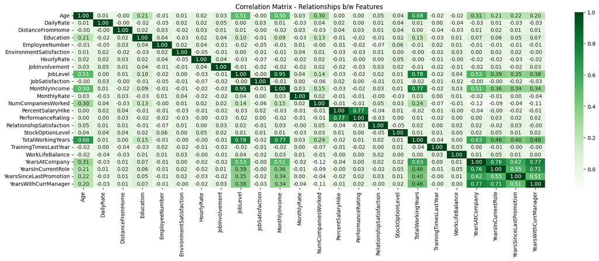

```python
plt.figure(figsize = (20, 6))
sns.heatmap(data = corr_matrix, annot = True, cmap = "Greens", fmt = ".2f")
plt.title("Correlation Matrix - Relationships b/w Features")
plt.show()
```

The strong positive correlations suggest relationships tied to career progression, such as higher **job levels**, **longer tenure**, and **increased income**. Weak or negligible correlations indicate that certain features may not significantly impact other variables in this dataset. From this insights, we could do further analysis, such as identifying factors influencing employee satisfaction or retention.

### Attrition vs. Numeric Features

**Compare **Monthly Income**, **Total Working Years**, and **Age** distributions for employees who left vs. stayed.**

```python
left_df
```

|  | Age | Attrition | BusinessTravel | DailyRate | Department | DistanceFromHome | Education | EducationField | EmployeeNumber | EnvironmentSatisfaction | ... | PerformanceRating | RelationshipSatisfaction | StockOptionLevel | TotalWorkingYears | TrainingTimesLastYear | WorkLifeBalance | YearsAtCompany | YearsInCurrentRole | YearsSinceLastPromotion | YearsWithCurrManager |
| --- | --- | --- | --- | --- | --- | --- | --- | --- | --- | --- | --- | --- | --- | --- | --- | --- | --- | --- | --- | --- | --- |
| 0 | 41 | Yes | Travel_Rarely | 1102 | Sales | 1 | 2 | Life Sciences | 1 | 2 | ... | 3 | 1 | 0 | 8 | 0 | 1 | 6 | 4 | 0 | 5 |
| 2 | 37 | Yes | Travel_Rarely | 1373 | Research & Development | 2 | 2 | Other | 4 | 4 | ... | 3 | 2 | 0 | 7 | 3 | 3 | 0 | 0 | 0 | 0 |
| 14 | 28 | Yes | Travel_Rarely | 103 | Research & Development | 24 | 3 | Life Sciences | 19 | 3 | ... | 3 | 2 | 0 | 6 | 4 | 3 | 4 | 2 | 0 | 3 |
| 21 | 36 | Yes | Travel_Rarely | 1218 | Sales | 9 | 4 | Life Sciences | 27 | 3 | ... | 4 | 2 | 0 | 10 | 4 | 3 | 5 | 3 | 0 | 3 |
| 24 | 34 | Yes | Travel_Rarely | 699 | Research & Development | 6 | 1 | Medical | 31 | 2 | ... | 3 | 3 | 0 | 8 | 2 | 3 | 4 | 2 | 1 | 3 |
| ... | ... | ... | ... | ... | ... | ... | ... | ... | ... | ... | ... | ... | ... | ... | ... | ... | ... | ... | ... | ... | ... |
| 1438 | 23 | Yes | Travel_Frequently | 638 | Sales | 9 | 3 | Marketing | 2023 | 4 | ... | 3 | 1 | 1 | 1 | 3 | 2 | 1 | 0 | 1 | 0 |
| 1442 | 29 | Yes | Travel_Rarely | 1092 | Research & Development | 1 | 4 | Medical | 2027 | 1 | ... | 3 | 2 | 3 | 4 | 3 | 4 | 2 | 2 | 2 | 2 |
| 1444 | 56 | Yes | Travel_Rarely | 310 | Research & Development | 7 | 2 | Technical Degree | 2032 | 4 | ... | 3 | 4 | 1 | 14 | 4 | 1 | 10 | 9 | 9 | 8 |
| 1452 | 50 | Yes | Travel_Frequently | 878 | Sales | 1 | 4 | Life Sciences | 2044 | 2 | ... | 3 | 4 | 2 | 12 | 3 | 3 | 6 | 3 | 0 | 1 |
| 1461 | 50 | Yes | Travel_Rarely | 410 | Sales | 28 | 3 | Marketing | 2055 | 4 | ... | 3 | 2 | 1 | 20 | 3 | 3 | 3 | 2 | 2 | 0 |

237 rows × 32 columns

```python
stayed_df
```

|  | Age | Attrition | BusinessTravel | DailyRate | Department | DistanceFromHome | Education | EducationField | EmployeeNumber | EnvironmentSatisfaction | ... | PerformanceRating | RelationshipSatisfaction | StockOptionLevel | TotalWorkingYears | TrainingTimesLastYear | WorkLifeBalance | YearsAtCompany | YearsInCurrentRole | YearsSinceLastPromotion | YearsWithCurrManager |
| --- | --- | --- | --- | --- | --- | --- | --- | --- | --- | --- | --- | --- | --- | --- | --- | --- | --- | --- | --- | --- | --- |
| 1 | 49 | No | Travel_Frequently | 279 | Research & Development | 8 | 1 | Life Sciences | 2 | 3 | ... | 4 | 4 | 1 | 10 | 3 | 3 | 10 | 7 | 1 | 7 |
| 3 | 33 | No | Travel_Frequently | 1392 | Research & Development | 3 | 4 | Life Sciences | 5 | 4 | ... | 3 | 3 | 0 | 8 | 3 | 3 | 8 | 7 | 3 | 0 |
| 4 | 27 | No | Travel_Rarely | 591 | Research & Development | 2 | 1 | Medical | 7 | 1 | ... | 3 | 4 | 1 | 6 | 3 | 3 | 2 | 2 | 2 | 2 |
| 5 | 32 | No | Travel_Frequently | 1005 | Research & Development | 2 | 2 | Life Sciences | 8 | 4 | ... | 3 | 3 | 0 | 8 | 2 | 2 | 7 | 7 | 3 | 6 |
| 6 | 59 | No | Travel_Rarely | 1324 | Research & Development | 3 | 3 | Medical | 10 | 3 | ... | 4 | 1 | 3 | 12 | 3 | 2 | 1 | 0 | 0 | 0 |
| ... | ... | ... | ... | ... | ... | ... | ... | ... | ... | ... | ... | ... | ... | ... | ... | ... | ... | ... | ... | ... | ... |
| 1465 | 36 | No | Travel_Frequently | 884 | Research & Development | 23 | 2 | Medical | 2061 | 3 | ... | 3 | 3 | 1 | 17 | 3 | 3 | 5 | 2 | 0 | 3 |
| 1466 | 39 | No | Travel_Rarely | 613 | Research & Development | 6 | 1 | Medical | 2062 | 4 | ... | 3 | 1 | 1 | 9 | 5 | 3 | 7 | 7 | 1 | 7 |
| 1467 | 27 | No | Travel_Rarely | 155 | Research & Development | 4 | 3 | Life Sciences | 2064 | 2 | ... | 4 | 2 | 1 | 6 | 0 | 3 | 6 | 2 | 0 | 3 |
| 1468 | 49 | No | Travel_Frequently | 1023 | Sales | 2 | 3 | Medical | 2065 | 4 | ... | 3 | 4 | 0 | 17 | 3 | 2 | 9 | 6 | 0 | 8 |
| 1469 | 34 | No | Travel_Rarely | 628 | Research & Development | 8 | 3 | Medical | 2068 | 2 | ... | 3 | 1 | 0 | 6 | 3 | 4 | 4 | 3 | 1 | 2 |

1233 rows × 32 columns

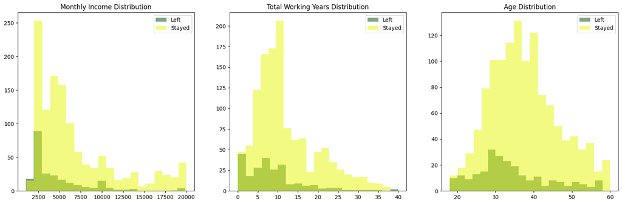

```python
plt.figure(figsize = (20, 6))

# Monthly Income
plt.subplot(1, 3, 1)
plt.hist(left_df["MonthlyIncome"], bins = 20, alpha = 0.5,
         color = "#004f15", label = "Left")
plt.hist(stayed_df["MonthlyIncome"], bins=20, alpha = 0.5,
         color = "#e7f705", label = "Stayed")
plt.title("Monthly Income Distribution")
plt.legend()

# Total Working Years
plt.subplot(1, 3, 2)
plt.hist(left_df["TotalWorkingYears"], bins = 20, alpha = 0.5,
         color = "#004f15", label = "Left")
plt.hist(stayed_df["TotalWorkingYears"], bins = 20, alpha = 0.5,
         color = "#e7f705", label = "Stayed")
plt.title("Total Working Years Distribution")
plt.legend()

# Age
plt.subplot(1, 3, 3)
plt.hist(left_df["Age"], bins = 20, alpha = 0.5,
         color = "#004f15", label = "Left")
plt.hist(stayed_df["Age"], bins = 20, alpha = 0.5,
         color = "#e7f705", label = "Stayed")
plt.title("Age Distribution")
plt.legend()

plt.show()
```

- **Monthly Income**: Employees who left seem to have lower income distributions compared to those who stayed.
- **Total Working Years**: Employees with fewer working years seem more likely to leave.
- **Age**: Younger employees have higher attrition, while older employees tend to stay.

**Use violin plots or box plots for better visualization.**

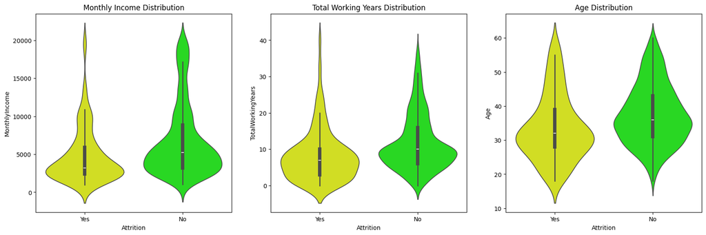

```python
plt.figure(figsize = (20, 6))

# Monthly Income
plt.subplot(1, 3, 1)
sns.violinplot(data = df, x = "Attrition", y = "MonthlyIncome",
               hue = "Attrition", palette = ["#ecfc05", "#0df505"])
plt.title("Monthly Income Distribution")

# Total Working Years
plt.subplot(1, 3, 2)
sns.violinplot(data = df, x = "Attrition", y = "TotalWorkingYears",
               hue = "Attrition", palette = ["#ecfc05", "#0df505"])
plt.title("Total Working Years Distribution")

# Age
plt.subplot(1, 3, 3)
sns.violinplot(data = df, x = "Attrition", y = "Age",
               hue = "Attrition", palette = ["#ecfc05", "#0df505"])
plt.title("Age Distribution")

plt.show()
```

- **Monthly Income**: Clear gap in distribution—lower-income employees are more likely to leave.
- **Total Working Years**: Employees with shorter careers show higher attrition, reinforcing the histogram trend.
- **Age**: The younger demographic faces more attrition, possibly due to career shifts or better opportunities.

**Low salary, fewer years of experience, and younger age = Higher Attrition Risk**

### Attrition vs. Categorical Features

**Create count plots for categorical variables like **Job Role**, **Department**, **Education Field** segmented by **Attrition**.**

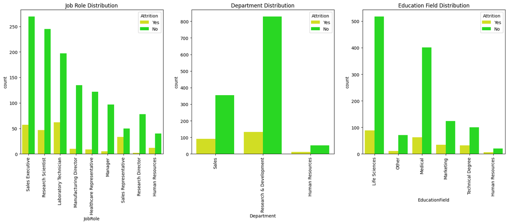

```python
plt.figure(figsize = (20, 6))

# Job Role
plt.subplot(1, 3, 1)
sns.countplot(data = df, x = "JobRole",
               hue = "Attrition", palette = ["#ecfc05", "#0df505"])
plt.title("Job Role Distribution")
plt.xticks(rotation = 90)

# Department
plt.subplot(1, 3, 2)
sns.countplot(data = df, x = "Department",
               hue = "Attrition", palette = ["#ecfc05", "#0df505"])
plt.title("Department Distribution")
plt.xticks(rotation = 90)

# Education Field
plt.subplot(1, 3, 3)
sns.countplot(data = df, x = "EducationField",
               hue = "Attrition", palette = ["#ecfc05", "#0df505"])
plt.title("Education Field Distribution")
plt.xticks(rotation = 90)

plt.show()
```

**Department**

- The **Research & Development** department has the largest workforce, but it also experiences substantial attrition, although the majority of employees stay.
- The **Sales** department shows a relatively higher proportion of attrition compared to its total workforce.
- The **Human Resources** department has the smallest workforce and exhibits minimal attrition.

**Education Field**